# Qualidade de Vinhos Tintos por Nailson dos Santos

# Seção de Gráficos Univariados

# Análise Univariada

### Qual é a estrutura do conjunto de dados?

```r
str(vinhos)
```

```
## 'data.frame':    1599 obs. of  13 variables:
##  $ X                   : int  1 2 3 4 5 6 7 8 9 10 ...
##  $ fixed.acidity       : num  7.4 7.8 7.8 11.2 7.4 7.4 7.9 7.3 7.8 7.5 ...
##  $ volatile.acidity    : num  0.7 0.88 0.76 0.28 0.7 0.66 0.6 0.65 0.58 0.5 ...
##  $ citric.acid         : num  0 0 0.04 0.56 0 0 0.06 0 0.02 0.36 ...
##  $ residual.sugar      : num  1.9 2.6 2.3 1.9 1.9 1.8 1.6 1.2 2 6.1 ...
##  $ chlorides           : num  0.076 0.098 0.092 0.075 0.076 0.075 0.069 0.065 0.073 0.071 ...
##  $ free.sulfur.dioxide : num  11 25 15 17 11 13 15 15 9 17 ...
##  $ total.sulfur.dioxide: num  34 67 54 60 34 40 59 21 18 102 ...
##  $ density             : num  0.998 0.997 0.997 0.998 0.998 ...
##  $ pH                  : num  3.51 3.2 3.26 3.16 3.51 3.51 3.3 3.39 3.36 3.35 ...
##  $ sulphates           : num  0.56 0.68 0.65 0.58 0.56 0.56 0.46 0.47 0.57 0.8 ...
##  $ alcohol             : num  9.4 9.8 9.8 9.8 9.4 9.4 9.4 10 9.5 10.5 ...
##  $ quality             : int  5 5 5 6 5 5 5 7 7 5 ...
```

Adicional ao que é exibido na função str(), de acordo com o arquivo *wineQualytiInfo.txt* obtido do repositório da Udacity no endereço https://s3.amazonaws.com/udacity-hosted-downloads/ud651/wineQualityInfo.txt, o conjunto de dados tem a seguinte estrutura de variáveis:

**Input variables (based on physicochemical tests):**

1. **fixed acidity** (tartaric acid - g / dm^3)
2. **volatile acidity** (acetic acid - g / dm^3)
3. **citric acid** (g / dm^3)
4. **residual sugar** (g / dm^3)
5. **chlorides** (sodium chloride - g / dm^3
6. **free sulfur dioxide** (mg / dm^3)
7. **total sulfur dioxide** (mg / dm^3)
8. **density** (g / cm^3)
9. **pH**
10. **sulphates** (potassium sulphate - g / dm3)
11. **alcohol** (% by volume)

**Output variable (based on sensory data):**

12. **quality** (score between 0 and 10)

### Quais são os principais atributos de interesse deste conjunto de dados?

**QUALITY** é o atributo principal, pois ele define a qualidade do vinho baseado nos outros fatores.

**ALCOHOL** porque o teor alcoólico também influencia no paladar;

```r
summary(vinhos$quality)
```

```
##    Min. 1st Qu.  Median    Mean 3rd Qu.    Max.
##   3.000   5.000   6.000   5.636   6.000   8.000
```

```r
summary(vinhos$alcohol)
```

```
##    Min. 1st Qu.  Median    Mean 3rd Qu.    Max.
##    8.40    9.50   10.20   10.42   11.10   14.90
```

#### Analisando a distribuição das duas variáveis escolhidas como principais

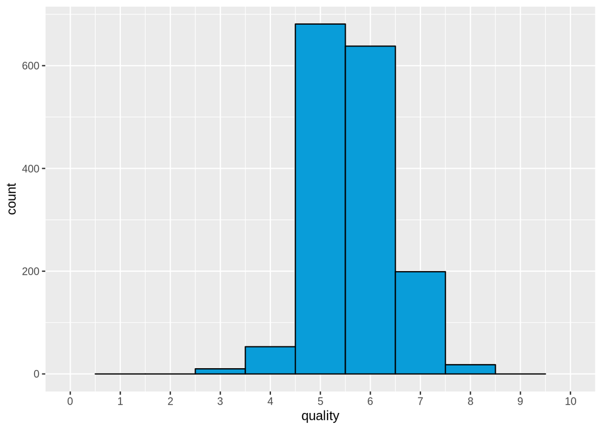

```r
ggplot(aes(x = quality), data = vinhos) +
    geom_histogram(color = 'black', fill = '#099DD9', binwidth = 1) +
    scale_x_continuous(breaks = seq(0, 10, 1), limits = c(0, 10))
```

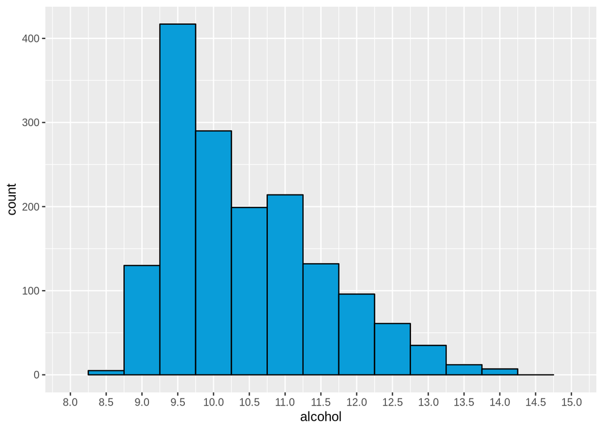

```r
ggplot(aes(x = alcohol), data = vinhos) +
    geom_histogram(color = 'black', fill = '#099DD9', binwidth = 0.5) +
    scale_x_continuous(breaks = seq(8, 15, 0.5), limits = c(8, 15))
```

#### Criando uma variável de categoria para agrupar qualidades de vinhos

Dado que a variável *quality* apresenta apenas números inteiros, ou seja, não teremos vinhos classificados com qualidade 6.8, por exemplo, serão criados grupos de qualidade.

```r
# Criando os grupos de qualidade
quality.group <- c(0, 2, 4, 6, 8, 10)

# Criando rótulos para os intervalos
group <- c('Pessimo', 'Ruim', 'Mediano', 'Bom', 'Otimo')

# Classificando os vinhos de acordo com os grupos criados
vinhos$class <- cut(vinhos$quality, quality.group, include.lowest = TRUE, right = FALSE, labels = group)
```

### Quais outros atributos você acha que podem lhe auxiliar na investigação destes atributos de interesse?

**DENSITY** porque pode refletir diretamente na sensação ao degustar o produto;

**PH** porque indica o nível de acidez sentido pelo apreciador do vinho;

```r
summary(vinhos$density)
```

```
##    Min. 1st Qu.  Median    Mean 3rd Qu.    Max.
##  0.9901  0.9956  0.9968  0.9967  0.9978  1.0037
```

```r
summary(vinhos$pH)
```

```
##    Min. 1st Qu.  Median    Mean 3rd Qu.    Max.
##   2.740   3.210   3.310   3.311   3.400   4.010
```

### Você criou novas variáveis a partir dos atributos existentes no conjunto de dados?

Foi criada a variável **class**, conforme descrito acima para classificar os vinhos em péssimos, ruins, medianos, bons e ótimos.

### Dos atributos investigados, distribuições incomuns foram encontradas? Você aplicou operações nos dados para limpá-los, ajustá-los ou mudar a forma dos dados? Se sim, por quê?

# Seção de Gráficos Bivariados

# Análise Bivariada

### Discuta sobre alguns dos relacionamentos observados nesta parte da investigação. Como os atributos de interesse variaram no conjunto de dados?

### Você observou algum relacionamento interessante entre os outros atributos (os que não são de interesse)?

### Qual foi o relacionamento mais forte encontrado?

# Seção de Gráficos Multivariados

# Análise Multivariada

### Discuta sobre os relacionamentos observados nesta parte da investigação. Quais atributos que fortaleceram os demais na observação das variáveis de interesse?

### Interações surpreendentes e/ou interessantes foram encontradas entre os atributos?

### OPCIONAL: Modelos foram criados usando este conjunto de dados? Discuta sobre os pontos fortes e as limitações do seu modelo.

# Gráficos Finais e Sumário

### Descrição do Terceiro Gráfico

# Reflexão